# Assignment 16: Writing a function - Loop

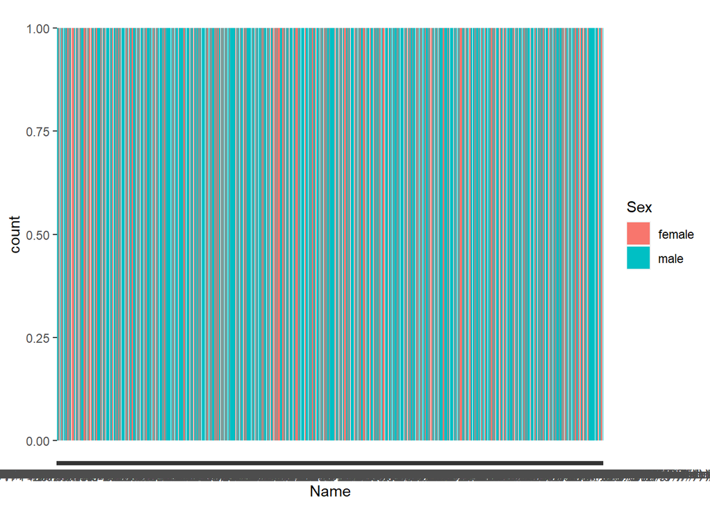

[figure not shown]

[figure not shown]

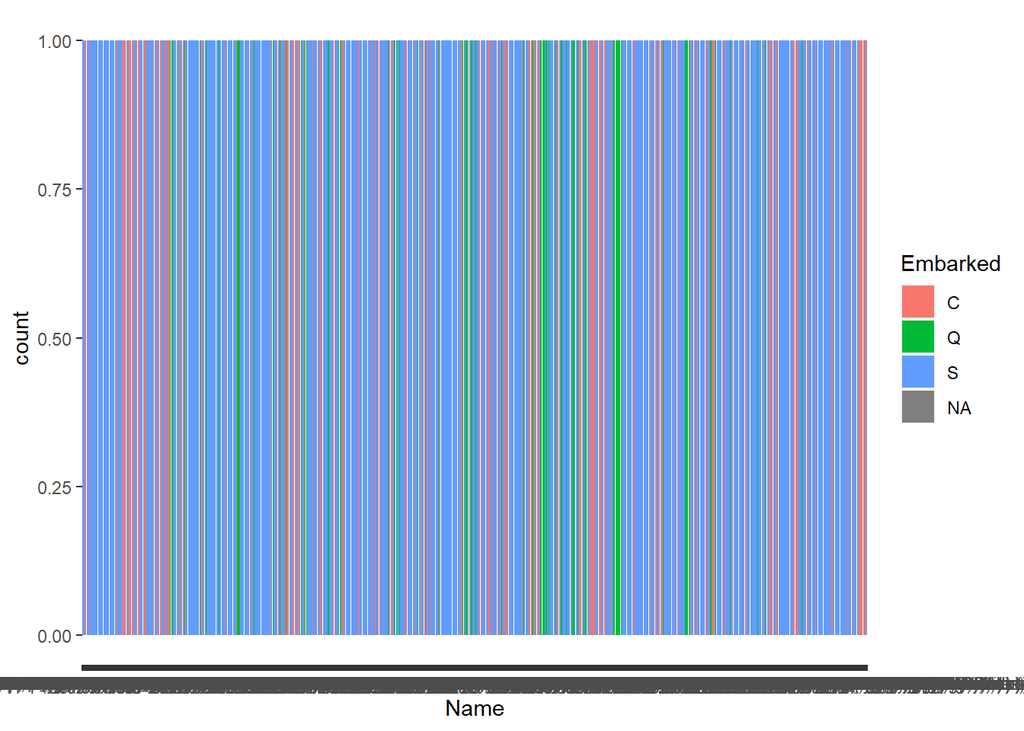

[figure not shown]

[figure not shown]

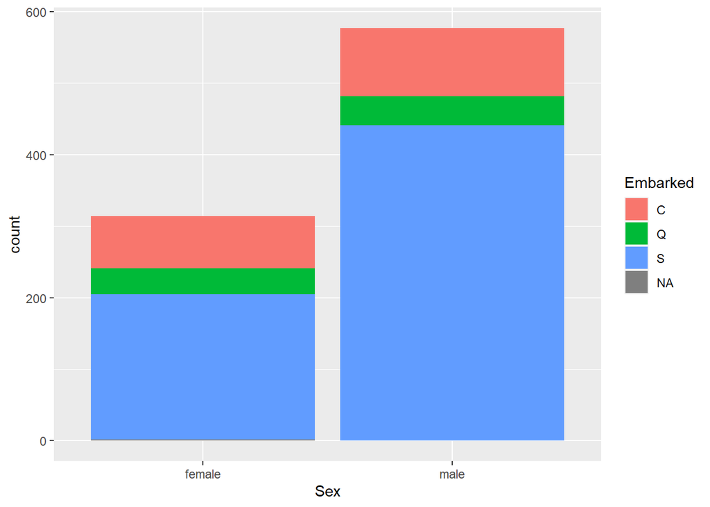

[figure not shown]

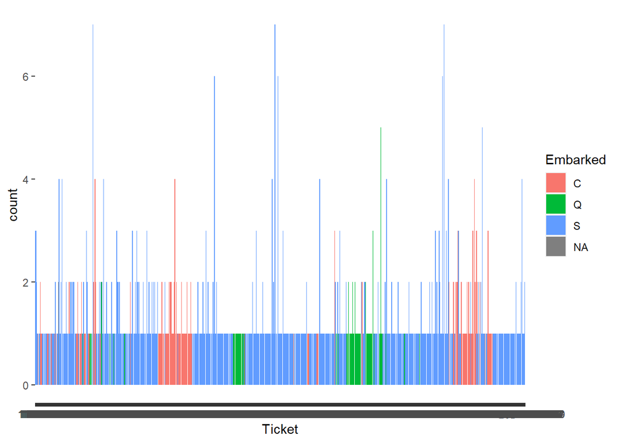

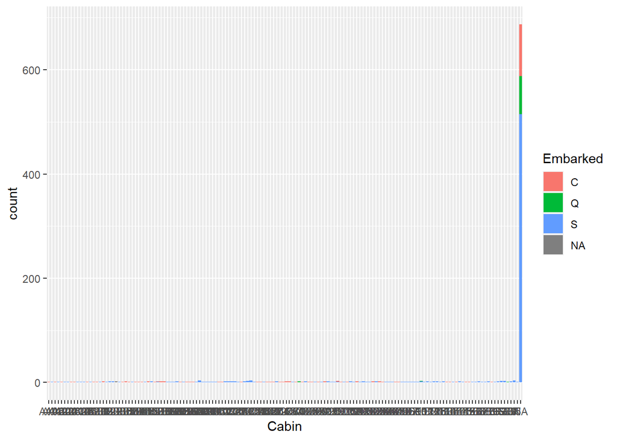

```r
bar_plot_all2 <- function(d)
{
  library(ggplot2)
  l <- length(d)
  for (i in 1:(l-1))
    for (j in (i+1):l)
  {
    if (!is.numeric(d[[i]])& (!is.numeric(d[[j]])))
    {
      print(ggplot(d, aes(x = d[[i]], fill = d[[j]]))+
              geom_bar()+labs(x = names(d)[i], fill = names(d)[j]))
    }
  }
}
#This code works, but the resulting graphs for the Titanic dataset look ridiculous because there are many different categories that have very few values (like Name, Cabin, etc)
bar_plot_all2(dfTitanic)
```

5. Write the following function. Give examples to test your function.
- Input: a data frame
- Output:
  - all possible the bar plots of a non-numeric variable filled by a non-numeric variable.
  - all possible the density plots of a numeric variable colored by a non-numeric variable
  - all possible the scatter plots.

Hint: Combine [this function](https://bryantstats.github.io/math421/gganimate/18_writing_functions_fa21.html#37), [this function](https://bryantstats.github.io/math421/gganimate/18_writing_functions_fa21.html#40), and the function in Question 4. One way to combine is creating a new function, `quick_plot`, and call these three functions within `quic_kplot`.

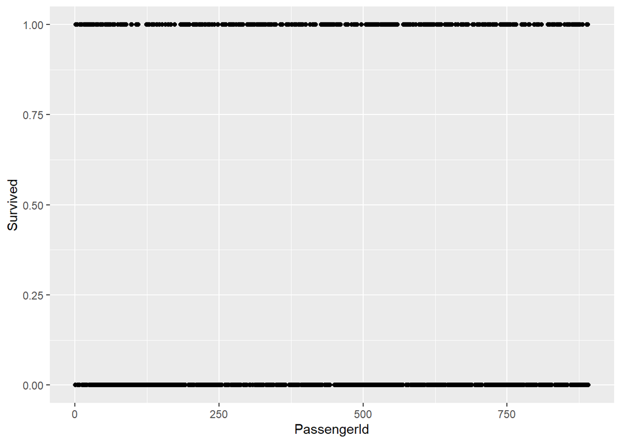

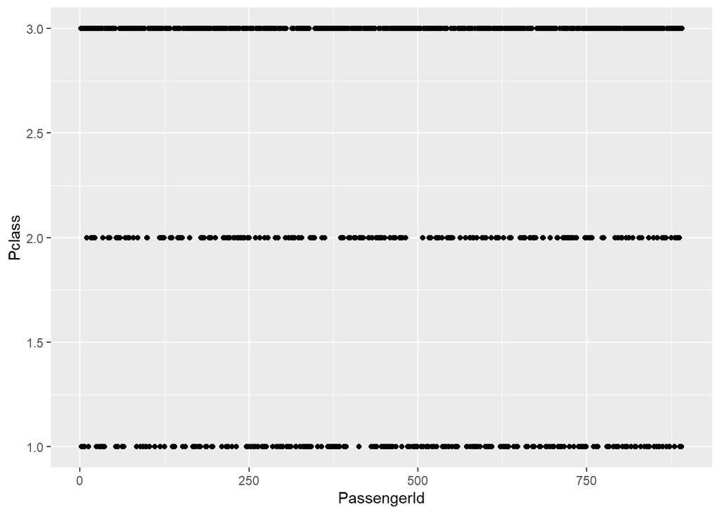

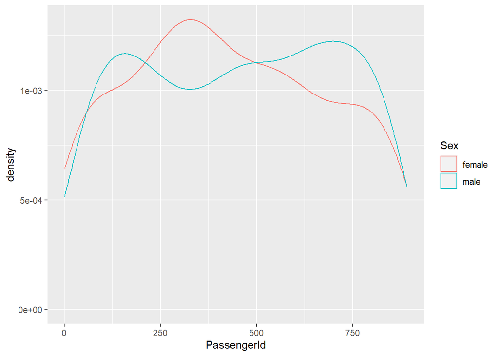

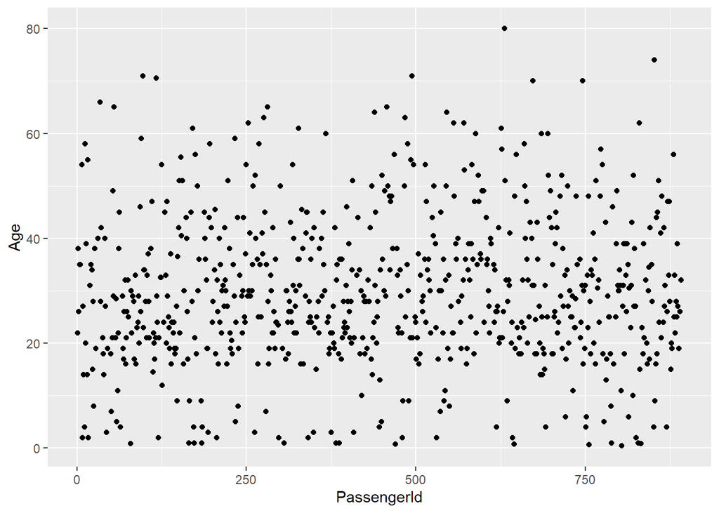

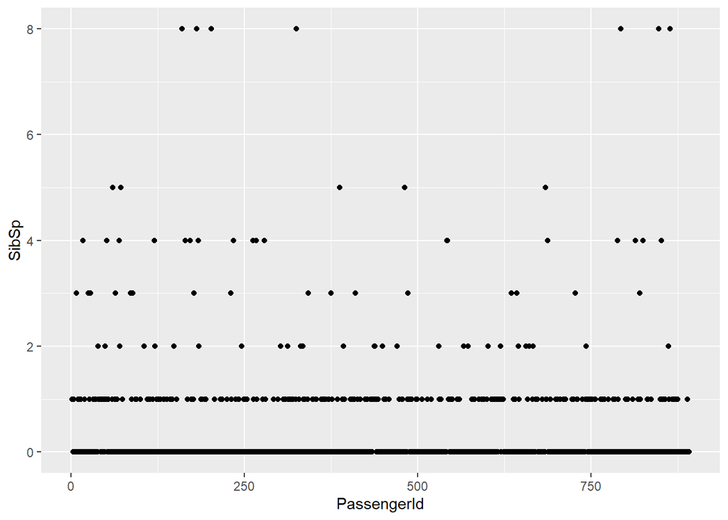

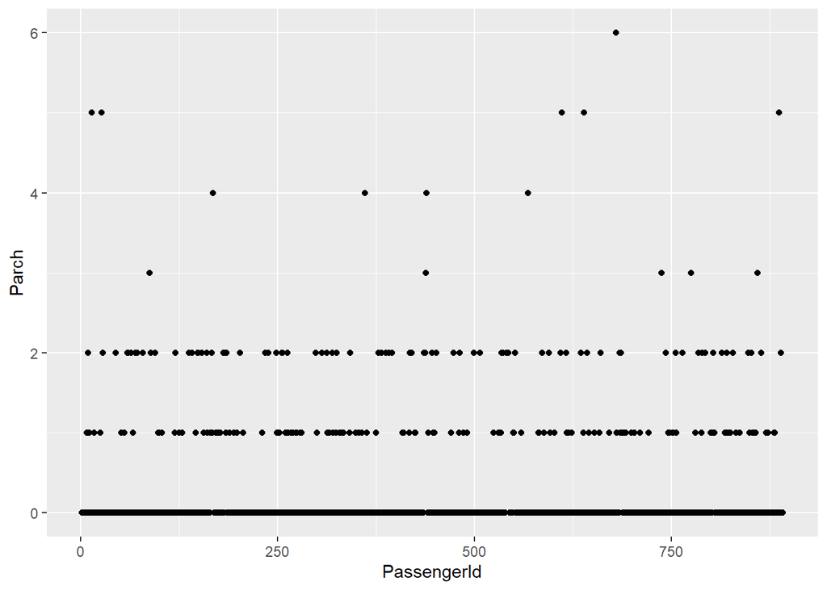

[figure not shown]

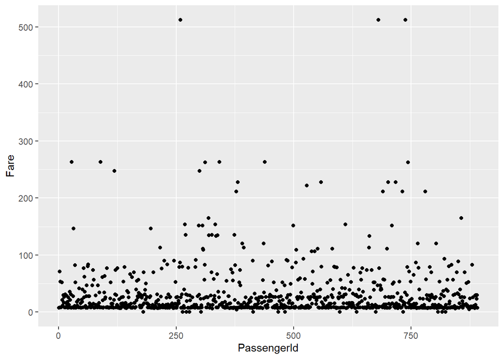

[figure not shown]

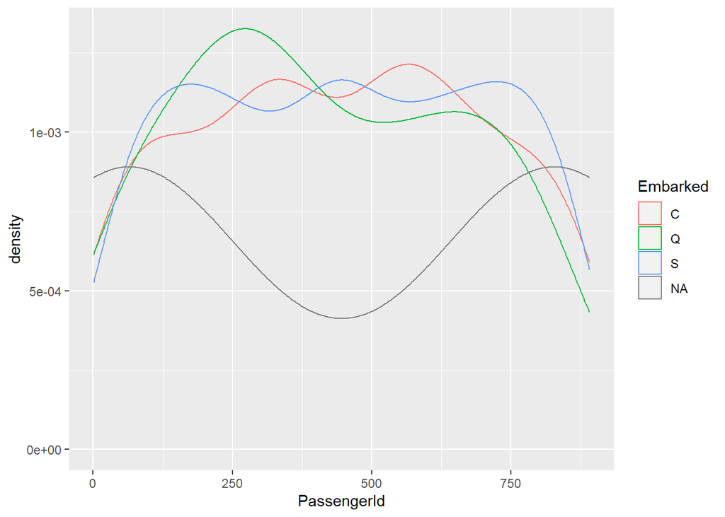

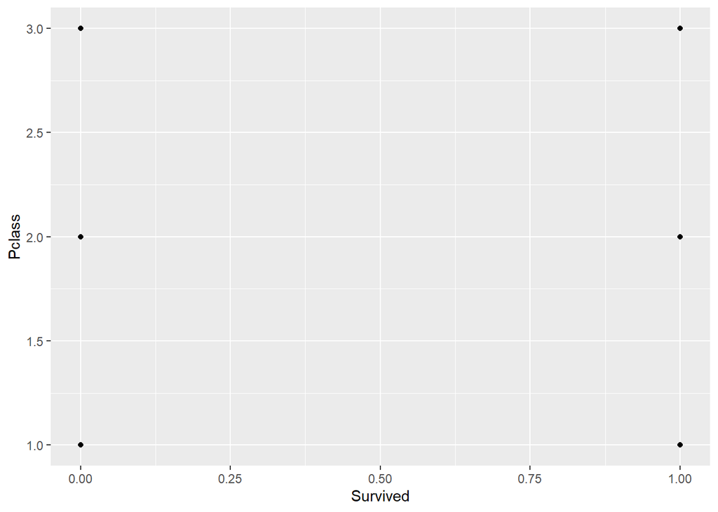

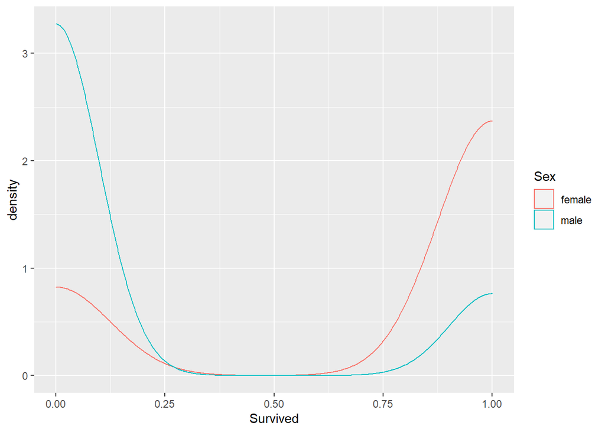

[38 more figures not shown]

```r
AllThePlots <- function(d)
{
  library(ggplot2)
  l <- length(d)
  for (i in 1:(l-1))
    for (j in (i+1):l)
  {
    if (!is.numeric(d[[i]])& (!is.numeric(d[[j]])))
    {
      print(ggplot(d, aes(x = d[[i]], fill = d[[j]]))+
              geom_bar()+labs(x = names(d)[i], fill = names(d)[j]))
    }

else if (is.numeric(d[[i]])& (!is.numeric(d[[j]])))
    {
      print(ggplot(d, aes(x = d[[i]], color = d[[j]]))+
              geom_density()+labs(x = names(d)[i], color = names(d)[j]))
}
      else if (is.numeric(d[[i]])&is.numeric(d[[j]]))
    {
      print(ggplot(d, aes(x = d[[i]], y = d[[j]]))+
              geom_point()+
              labs(x = names(d)[i], y = names(d)[j]))
    }

    }
}
dfTitanicSmall <- select(dfTitanic,-Name,-PassengerId,-SibSp,-Parch)
#Just to remove some columns
AllThePlots(dfTitanic)
```